## NLP Project exploration and results

#### Perceived Power and Submissiveness

Libby Heeren

# Importing reddit posts and comments

```python
from psaw import PushshiftAPI
import sys
import datetime as dt
import json
import pprint


api = PushshiftAPI() #instantiate pushshift API
start_epoch=int(dt.datetime(2010, 1, 1).timestamp()) # start datetime
end_epoch=int(dt.datetime(2021, 2, 20).timestamp()) # end datetime (in the future)

submission_result = api.search_submissions(after=start_epoch, # getting submissions, change to search_comments when needed
                                before=end_epoch,
                                #q = "General Questions Thread",
                                subreddit='WoT',
                                limit=1000000) # getting the most recent first, make this really large to try to get everything

outfile = open('WotRed.jsonl','w')
for i in submission_result:
    jdata = json.dumps(i.d_) # we are pulling the entire dicts here using i.d_
    outfile.write(jdata+'\n')# each id on a new line
    #pprint.pprint(i.d_) #uncomment this, delete under it, and add a break under in order to stop
    #print(i.d_['selftext']) # i.d_ is a dictionary for a submission, selftext is a key in the dict (it's the post text)
    #print(i.d_['title']) # title of submission
    #print(i.d_['url']) # url of submission
    # score is upvotes minus downvotes, but these are saved early on and are not updated
    #break
outfile.close() # every line in .json is a json object



# But not every post is a selfpost (a text post, which is what we want)

# just figure out self text first







    #ids.add(i.d_['id'])
    #my_d = api.search_comments(after=start_epoch,
                                #before=end_epoch,
                                #subreddit='WoT',
                                #limit=1000000000000000)
    #for i in my_d:
        #data = i.d_
        #if data['link_id'].split('_')[1] in ids:  # link_id needs to match
            #print(json.dumps(data))
```

# Grab Comments

```python
from psaw import PushshiftAPI
import sys
import datetime as dt
import json
import pprint


api = PushshiftAPI() #instantiate pushshift API
start_epoch=int(dt.datetime(2010, 1, 1).timestamp()) # start datetime
end_epoch=int(dt.datetime(2021, 2, 20).timestamp()) # end datetime (in the future)

comment_result = api.search_comments(after=start_epoch, # getting submissions, change to search_comments when needed
                                before=end_epoch,
                                #q = "General Questions Thread",
                                subreddit='WoT',
                                limit=1000000) # getting the most recent first, make this really large to try to get everything

outfile = open('WotRedComms.jsonl','w')
for i in comment_result:
    jdata = json.dumps(i.d_) # we are pulling the entire dicts here using i.d_
    outfile.write(jdata+'\n')# each id on a new line
    #pprint.pprint(i.d_) #uncomment this, delete under it, and add a break under in order to stop
    #print(i.d_['selftext']) # i.d_ is a dictionary for a submission, selftext is a key in the dict (it's the post text)
    #print(i.d_['title']) # title of submission
    #print(i.d_['url']) # url of submission
    # score is upvotes minus downvotes, but these are saved early on and are not updated
    #break
outfile.close() # every line in .json is a json object
```

# Grab selftext posts only

```python
from psaw import PushshiftAPI
import sys
import datetime as dt
import json
import pprint


api = PushshiftAPI() #instantiate pushshift API
start_epoch=int(dt.datetime(2010, 1, 1).timestamp()) # start datetime
end_epoch=int(dt.datetime(2021, 2, 20).timestamp()) # end datetime (in the future)

submission_result = api.search_submissions(after=start_epoch, # getting submissions, change to search_comments when needed
                                before=end_epoch,
                                #q = "General Questions Thread",
                                subreddit='WoT',
                                limit=1000000) # getting the most recent first, make this really large to try to get everything

outfile = open('WotRedSelf.jsonl','w')
for i in submission_result:
    jdata = json.dumps(i.d_) # we are pulling the entire dicts here using i.d_
    if 'selftext' in i.d_:
        outfile.write(jdata+'\n')# each id on a new line
    #pprint.pprint(i.d_) #uncomment this, delete under it, and add a break under in order to stop
    #print(i.d_['selftext']) # i.d_ is a dictionary for a submission, selftext is a key in the dict (it's the post text)
    #print(i.d_['title']) # title of submission
    #print(i.d_['url']) # url of submission
    # score is upvotes minus downvotes, but these are saved early on and are not updated
    #break
outfile.close() # every line in .json is a json object
```

# Get r/books posts and comments

```python
from psaw import PushshiftAPI
import sys
import datetime as dt
import json
import pprint


api = PushshiftAPI() #instantiate pushshift API
start_epoch=int(dt.datetime(2010, 10, 1).timestamp()) # start datetime
end_epoch=int(dt.datetime(2021, 2, 20).timestamp()) # end datetime (in the future)

submission_result = api.search_submissions(after=start_epoch, # getting submissions, change to search_comments when needed
                                before=end_epoch,
                                #q = "General Questions Thread",
                                subreddit='books',
                                limit=50000) # getting the most recent first, make this really large to try to get everything

outfile = open('rbooksSelf.jsonl','w')
for i in submission_result:
    jdata = json.dumps(i.d_) # we are pulling the entire dicts here using i.d_
    if 'selftext' in i.d_:
        outfile.write(jdata+'\n')# each id on a new line
outfile.close() # every line in .json is a json object


comment_result = api.search_comments(after=start_epoch, # getting submissions, change to search_comments when needed
                                before=end_epoch,
                                #q = "General Questions Thread",
                                subreddit='books',
                                limit=50000) # getting the most recent first, make this really large to try to get everything

outfile = open('rbooksComms.jsonl','w')
for i in comment_result:
    jdata = json.dumps(i.d_) # we are pulling the entire dicts here using i.d_
    outfile.write(jdata+'\n')# each id on a new line
outfile.close() # every line in .json is a json object
```

# Count total posts

```python
# Count how many posts total and how many selftext posts
import json
infile = open('WotRed.jsonl', 'r')

linecount = 0

for line in infile: # looping over our jsonl line by line
    linecount += 1

infile.close()

print(linecount)
```

```
37291
```

# Count selftext posts

```python
# Count how many posts total and how many selftext posts
import json
infile = open('WotRedSelf.jsonl', 'r')

linecount = 0

for line in infile: # looping over our jsonl line by line
    linecount += 1

infile.close()

print(linecount)
```

```
37249
```

```python
infile = open('WotRed.jsonl', 'r')
import json
linecount = 0

for line in infile: # looping over our jsonl line by line
    data = json.loads(line) # data is a python dictionary containing one post (loads converts jsonl to dict)
    if 'selftext' in data: # if selftext appears as a key in dictionary, then
        #print(data['title'])  # print the title of the post
        linecount += 1

infile.close()

print(linecount)

# There are 37,291 posts total, and 37,249 of them are selftext posts

# ??????? How do I isolate just these selftext posts? Should I isolate when reading in?
# yes, that worked
```

```
37249
```

# Count Comments

```python
import json
infile = open('WotRedComms.jsonl', 'r')

linecount = 0

for line in infile: # looping over our jsonl line by line
    linecount += 1

infile.close()

print(linecount)
```

```
769547
```

```python
# borrowing from prev assn


import json

def json_string_to_dictionary(json_string):
    jsonObject = json.loads(json_string)
    return jsonObject


# json.dumps() function converts a Python object into a json string.
```

[output not shown]

```python
twitter_dataset = open('puerto-rico.jsonl', 'r')

for row in twitter_dataset:
    tweet_dict = json_string_to_dictionary(row)  # Reads one tweet into a dictionary



    tweet_text = tweet_dict['full_text']  # Pulls out the full text of the tweet and stores it as a string
    total_number_of_tweets += 1
    screenName = tweet_dict['user']['screen_name']  # Pulls out the screen name and saves it as a string
    TweetsPerUser[screenName] = TweetsPerUser.get(screenName, 0) + 1


    num_pos_words = count_sentiment_words(positive_words, tweet_text, True)  # Reads the full text and returns a count of pos words

    num_neg_words = count_sentiment_words(negative_words, tweet_text, True)  # Reads the full text and returns a count of neg words


    sentiment_prediction = predict(num_pos_words, num_neg_words)  # Arrives as a decision of positive, negative, or neutral for the tweet
    if sentiment_prediction == "positive":
        total_number_of_positive_tweets += 1
    elif sentiment_prediction == "negative":
        total_number_of_negative_tweets += 1
    elif sentiment_prediction == "neutral":
        total_number_of_neutral_tweets += 1


    sentiment_score = predict_score(num_pos_words, num_neg_words)  # Returns a score, <0 being more negative and >0 being more positive
    if sentiment_score < mostNegScore:
        mostNegScore = sentiment_score
        most_negative_tweet = tweet_text
    elif sentiment_score > mostPosScore:
        mostPosScore = sentiment_score
        most_positive_tweet = tweet_text



    # Your code should do the following:
    #   1. Keep track of the number of tweets
#done
    #   2. Keep track of the number of positive and negative tweets
#done
    #   3. Keep track of the user that tweet the most

for name, number in TweetsPerUser.items():
    if number > maxTweets:
        maxTweets = number
        user_with_most_tweets = name

    #   4. Keep track of the total number of unique users
total_number_of_users =len(TweetsPerUser)
    #   5. Keep track of the average number of tweets per user (how many tweets does each user make, on average)
average_number_tweets_per_user = total_number_of_tweets/total_number_of_users
    #   6. Keep track of the most positive and negative tweets.
#done


twitter_dataset.close()
```

```python
infile = open('WotRed.jsonl','r')
for i in submission_result:
    jdata = json.dumps(i.d_) # we are pulling the entire dicts here using i.d_
    outfile.write(jdata+'\n')# each id on a new line
    #pprint.pprint(i.d_) #uncomment this, delete under it, and add a break under in order to
    #print(i.d_['selftext']) # i.d_ is a dictionary for a submission, selftext is a key in the dict (it's the post text)
    #print(i.d_['title']) # title of submission
    #print(i.d_['url']) # url of submission
    # score is upvotes minus downvotes, but these are saved early on and are not updated
    #break
infile.close() # every line in .json is a json object



# But not every post is a selfpost (a text post, which is what we want)

# just figure out self text first
```

```python
infile = open('WotRed.jsonl', 'r')

linecount = 0

for line in infile: # looping over our jsonl line by line
    # data is a dict, each entry is a jsonl line
    data = json.loads(line) # data is a python dictionary (loads converts jsonl to dict)
    if 'selftext' in data: # if selftext as a key appears in dictionary, then print the title of the selftext post
        #print(data['title'])
        self_text = data['selftext']

infile.close()

print(linecount)


# count average number of words per selftext (total words in selftext/number of posts)
#split() ok for now

# try the same sentiment analysis we did in PS3

# count posts total vs selftext posts

# most frequently used words (maybe figure out how to remove stopwords) (and informative words - scoring on not just frequency)
# look in NLTK and scikitlearn for stopwords

# maybe switch lexicon to political or hate speech or perceived power once it works

# lexicon induction - what is the Wot reddit's own vocab?

# most frequently used words (maybe figure out how to remove stopwords)
```

# Figure out how to use stopwords and count chars

```python
data = 'aaabbcdddd'
```

```python
charcounts = {}

for c in data:
    if c in charcounts:
        charcounts[c] += 1
    else:
        charcounts[c] = 1

# first loop, c will equal 'a'
print(charcounts)
```

```
{'a': 3, 'b': 2, 'c': 1, 'd': 4}
```

```python
charcounts = {}

for c in data:
    charcounts[c] = charcounts.get(c, 0) + 1

print(charcounts)

# get is doing the same as above, if c is in the dict, it returns the value of c, if not
# it initializes the key and makes it 0, and then increments it to 1

# the next time we see that key, it will check for that key, see that it exists, and increment it by 1 (the +1)
```

```
{'a': 3, 'b': 2, 'c': 1, 'd': 4}
```

```python
data = " the dog and the sailor were best friends, but the storm separated them."
stopwords = {'and', 'the'}
charcounts = dict()
for c in data.split(" "):
    if c not in stopwords:
        charcounts[c] = charcounts.get(c, 0) + 1

print(charcounts)
```

```
{'': 1, 'dog': 1, 'sailor': 1, 'were': 1, 'best': 1, 'friends,': 1, 'but': 1, 'storm': 1, 'separated': 1, 'them.': 1}
```

```python
from sklearn.feature_extraction import text

print(text.ENGLISH_STOP_WORDS)

#print(stop_words.ENGLISH_STOP_WORDS)
```

```
frozenset({'rather', 'has', 'through', 'side', 'alone', 'somewhere', 'everyone', 'since', 'call', 'would', 'three', 'became', 'yet', 'next', 'amount', 'herein', 'myself', 'across', 'seem', 'hers', 'will', 'any', 'were', 'sincere', 'get', 'upon', 'cant', 'either', 'serious', 'often', 'hundred', 'too'…
```

### Remembering how to write a file to save and then access to assign to an object

```python
o_file = open('test.txt', 'w')

o_file.write('kfldj;akdl;jkslajfdlksajfd;slkaj;daslkfdjs;aflkdjas;')

o_file.close()

f1 = open('test.txt')

book1_txt = f1.read()[:10]

print(book1_txt)

f1.close()
```

```
kfldj;akdl
```

# Learn how to use datetime

```python
# created_utc": is the date of posting component of the json object

import datetime

print(f'Current date/time: {datetime.datetime.now()}')
```

```
Current date/time: 2021-03-05 10:46:35.037722
```

```python
date_utc = 1613800321
```

```python
datetime.datetime.utcfromtimestamp(date_utc)
```

```
datetime.datetime(2021, 2, 20, 5, 52, 1)
```

```python
date = datetime.datetime.utcfromtimestamp(date_utc)
```

```python
date.month
```

```
2
```

```python
date.strftime('%m')
```

```
'02'
```

```python
date.isocalendar()[1] # gets the week of the year
```

```
7
```

```python
date.day
```

```
20
```

```python
date.year
```

```
2021
```

```python
date.hour
```

```
5
```

```python
date.minute
```

```
52
```

```python
date.second
```

```
1
```

# Post + Comment Frequencies, plus mentions of 'the show'

```python
import json

def json_string_to_dictionary(json_string):
    jsonObject = json.loads(json_string)
    return jsonObject
```

```python
# calculating frequency of posts per YearMonth
import datetime
import json
import string

def json_string_to_dictionary(json_string):
    jsonObject = json.loads(json_string)
    return jsonObject

yearcounts = {} # dict of post counts by Year+Month as integer so it can be sorted
PostsByYear = {} # dict of post counts by year only
showMentionsbyMonth = {} # dict of mentions of "show" by YearMonth
TheShowMentionsbyMonth = {} # dict of mentions of "the show" by YearMonth (this one worked better)

###########################
Wot_dataset = open('WotRedSelf.jsonl', 'r')

for row in Wot_dataset:
    post_dict = json_string_to_dictionary(row)  # Reads one post into a dictionary

    if post_dict['selftext'] != "[deleted]":

        post_text = post_dict['selftext']  # Pulls out the full text of the post and stores it as a string
        if post_text == "":
            continue
        post_utc = post_dict['created_utc']
        post_date = datetime.datetime.utcfromtimestamp(post_utc) # (year, month, week of the year, hour, minute, second)
        year = post_date.year # pulling year as integer, like 2019
        month = post_date.strftime('%m') # pulling month as string with leading zero, like "08" for Aug
        yearcounts[int(str(year)+month)] = yearcounts.get(int(str(year)+month), 0) + 1
        PostsByYear[str(year)] = PostsByYear.get(str(year), 0) + 1
        if 'the show' in post_text:   # looking for "the show" before splitting post into discrete words
            TheShowMentionsbyMonth[int(str(year)+month)] = TheShowMentionsbyMonth.get(int(str(year)+month), 0) + 1
        for word in post_text.split():
            word = word.translate(str.maketrans('', '', string.punctuation)).lower() # split post into words
            if word == 'show': # just looking for the word "show" which wasn't as helpful
                showMentionsbyMonth[int(str(year)+month)] = showMentionsbyMonth.get(int(str(year)+month), 0) + 1
Wot_dataset.close()

Wot_dataset = open('WotRedComms.jsonl', 'r')

for row in Wot_dataset:
    post_dict = json_string_to_dictionary(row)  # Reads one post into a dictionary

    if post_dict['body'] != "[deleted]":

        post_text = post_dict['body']  # Pulls out the full text of the comm and stores it as a string
        if post_text == "":
            continue
        post_utc = post_dict['created_utc']
        post_date = datetime.datetime.utcfromtimestamp(post_utc) # (year, month, week of the year, hour, minute, second)
        year = post_date.year # pulling year as integer, like 2019
        month = post_date.strftime('%m') # pulling month as string with leading zero, like "08" for Aug
        yearcounts[int(str(year)+month)] = yearcounts.get(int(str(year)+month), 0) + 1
        PostsByYear[str(year)] = PostsByYear.get(str(year), 0) + 1
        if 'the show' in post_text:   # looking for "the show" before splitting post into discrete words
            TheShowMentionsbyMonth[int(str(year)+month)] = TheShowMentionsbyMonth.get(int(str(year)+month), 0) + 1
        for word in post_text.split():
            word = word.translate(str.maketrans('', '', string.punctuation)).lower() # split post into words
            if word == 'show': # just looking for the word "show" which wasn't as helpful
                showMentionsbyMonth[int(str(year)+month)] = showMentionsbyMonth.get(int(str(year)+month), 0) + 1
Wot_dataset.close()
```

```python
PostsByYear # Frequency of posts by year, notice it's sorted backwards in time
```

```
{'2021': 20635,
 '2020': 184771,
 '2019': 208875,
 '2018': 101879,
 '2017': 62103,
 '2016': 53200,
 '2015': 50685,
 '2014': 28538,
 '2013': 41536,
 '2012': 31489,
 '2011': 2309,
 '2010': 47}
```

```python
yearcounts
```

```
{202102: 5981,
 202101: 14654,
 202012: 15202,
 202011: 10643,
 202010: 13378,
 202009: 14006,
 202008: 20389,
 202007: 18270,
 202006: 16516,
 202005: 18090,
 202004: 13504,
 202003: 14490,
 202002: 15065,
 202001: 15218,
 201912: 16386,
```

[output cut: 110 more lines]

```python
showMentionsbyMonth
```

```
{202102: 380,
 202101: 620,
 202012: 530,
 202011: 327,
 202010: 425,
 202009: 623,
 202008: 1300,
 202007: 640,
 202006: 570,
 202005: 616,
 202004: 571,
 202003: 470,
 202002: 602,
 202001: 943,
 201912: 1052,
```

[output cut: 102 more lines]

```python
TheShowMentionsbyMonth
```

```
{202102: 169,
 202101: 236,
 202012: 194,
 202011: 108,
 202010: 161,
 202009: 227,
 202008: 531,
 202007: 234,
 202006: 182,
 202005: 248,
 202004: 204,
 202003: 181,
 202002: 247,
 202001: 367,
 201912: 434,
```

[output cut: 86 more lines]

On April 20, 2017, it was announced that Sony Pictures Television was producing a new adaptation of the book series in association with Red Eagle Entertainment and Radar Pictures.

On October 2, 2018, it was announced that Amazon had given the production a series order. Additionally, it was further announced that Amazon Studios would serve as a production company for the series.

On February 19, 2019, Uta Briesewitz was confirmed as director for the first two episodes.

It was announced in June 2019 that Rosamund Pike had been cast as the lead in the series as Moiraine.

Further main cast members were announced in August 2019: Daniel Henney as Lan Mandragoran, Josha Stradowski as Rand al'Thor, Marcus Rutherford as Perrin Aybara, Zoë Robins as Nynaeve al'Meara, Barney Harris as Mat Cauthon, and Madeleine Madden as Egwene al'Vere.

```python
import pandas as pd
pd.set_option("display.max_rows", None, "display.max_columns", None)
```

```python
monthNumbers = list(reversed(range(1, len(yearcounts)+1)))
yearNumbers = list(reversed(range(1, len(PostsByYear)+1)))
```

```python
YearMonth = list(yearcounts.keys())
Frequencies = list(yearcounts.values())
data = {'YearMonth': YearMonth, 'Frequency': Frequencies}
# df = pd.DataFrame(YearMonth, Frequencies, index = range(len(yearcounts)))
# df

FreqFrame = pd.DataFrame(columns = ['YearMonth', 'Frequency'], data = data, index = monthNumbers)
```

```python
FreqFrame = FreqFrame.sort_values(by='YearMonth')
FreqFrame
```

|  | YearMonth | Frequency |
| --- | --- | --- |
| 1 | 201010 | 3 |
| 6 | 201011 | 41 |
| 2 | 201012 | 3 |
| 7 | 201101 | 2 |
| 3 | 201102 | 1 |
| 8 | 201103 | 5 |
| 4 | 201104 | 3 |
| 5 | 201105 | 2 |
| 9 | 201106 | 54 |
| 10 | 201107 | 133 |
| 11 | 201108 | 363 |
| 12 | 201109 | 374 |
| 13 | 201110 | 546 |
| 14 | 201111 | 365 |
| 15 | 201112 | 461 |
| 16 | 201201 | 878 |
| 17 | 201202 | 973 |
| 18 | 201203 | 1454 |
| 19 | 201204 | 1437 |
| 20 | 201205 | 1099 |
| 21 | 201206 | 1723 |
| 22 | 201207 | 2178 |
| 23 | 201208 | 2192 |
| 24 | 201209 | 2833 |
| 25 | 201210 | 4571 |
| 26 | 201211 | 5935 |
| 27 | 201212 | 6216 |
| 28 | 201301 | 13699 |
| 29 | 201302 | 5101 |
| 30 | 201303 | 4093 |

[output cut: 95 more lines]

```python
# We want to make a dataframe of the frequencies over time, but have years sorted smallest to largest
# so they can be plotted over time correctly, 2011-2021, instead of 2021-2011
import pandas as pd
pd.set_option("display.max_rows", None, "display.max_columns", None) # allows pandas to print entire dataframe instead of shortening it

yearNumbers = list(reversed(range(1, len(PostsByYear)+1))) # create a reversed index of number of years
Year = list(PostsByYear.keys()) # create a list of years from the dict keys
Frequency = list(PostsByYear.values()) # create a list of frequencies from the dict values
yeardata = {'Year': Year, 'Frequency': Frequency} # create a new dict with the year and frequency values

# make a dataframe in pandas out of the data dict you just made, index by your backwards index
YearFreqFrame = pd.DataFrame(columns = ['Year', 'Frequency'], data = yeardata, index = yearNumbers)
YearFreqFrame = YearFreqFrame.sort_values(by='Year') # sort the dataframe by year so it goes in time order
YearFreqFrame
```

|  | Year | Frequency |
| --- | --- | --- |
| 1 | 2010 | 47 |
| 2 | 2011 | 2309 |
| 3 | 2012 | 31489 |
| 4 | 2013 | 41536 |
| 5 | 2014 | 28538 |
| 6 | 2015 | 50685 |
| 7 | 2016 | 53200 |
| 8 | 2017 | 62103 |
| 9 | 2018 | 101879 |
| 10 | 2019 | 208875 |
| 11 | 2020 | 184771 |
| 12 | 2021 | 20635 |

```python
import collections
TheShowMentionsbyMonthSorted = collections.OrderedDict(sorted(TheShowMentionsbyMonth.items()))
monthNumbersShow = list(range(1, len(TheShowMentionsbyMonthSorted)+1))
YearMonthShow = list(TheShowMentionsbyMonthSorted.keys())
FrequenciesShow = list(TheShowMentionsbyMonthSorted.values())
dataShow = {'YearMonth': YearMonthShow, 'Frequency': FrequenciesShow}
# df = pd.DataFrame(YearMonth, Frequencies, index = range(len(yearcounts)))
# df
FreqFrameShow = pd.DataFrame(columns = ['YearMonth', 'Frequency'], data = dataShow, index = monthNumbersShow)

#FreqFrameShow = FreqFrameShow.sort_values(by='YearMonth')
FreqFrameShow
```

|  | YearMonth | Frequency |
| --- | --- | --- |
| 1 | 201203 | 1 |
| 2 | 201204 | 3 |
| 3 | 201205 | 2 |
| 4 | 201206 | 1 |
| 5 | 201207 | 1 |
| 6 | 201208 | 2 |
| 7 | 201209 | 4 |
| 8 | 201210 | 1 |
| 9 | 201211 | 2 |
| 10 | 201212 | 3 |
| 11 | 201301 | 6 |
| 12 | 201303 | 3 |
| 13 | 201304 | 6 |
| 14 | 201306 | 2 |
| 15 | 201307 | 2 |
| 16 | 201308 | 12 |
| 17 | 201309 | 1 |
| 18 | 201310 | 1 |
| 19 | 201311 | 8 |
| 20 | 201312 | 3 |
| 21 | 201401 | 3 |
| 22 | 201405 | 1 |
| 23 | 201406 | 2 |
| 24 | 201407 | 7 |
| 25 | 201408 | 3 |
| 26 | 201409 | 6 |
| 27 | 201410 | 4 |
| 28 | 201411 | 4 |
| 29 | 201412 | 10 |
| 30 | 201502 | 59 |

[output cut: 71 more lines]

```python
TheShowMentionsbyMonthSorted
```

```
OrderedDict([(201203, 1),
             (201204, 3),
             (201205, 2),
             (201206, 1),
             (201207, 1),
             (201208, 2),
             (201209, 4),
             (201210, 1),
             (201211, 2),
             (201212, 3),
             (201301, 6),
             (201303, 3),
             (201304, 6),
             (201306, 2),
             (201307, 2),
             (201308, 12),
             (201309, 1),
             (201310, 1),
             (201311, 8),
             (201312, 3),
             (201401, 3),
             (201405, 1),
             (201406, 2),
             (201407, 7),
             (201408, 3),
             (201409, 6),
             (201410, 4),
             (201411, 4),
             (201412, 10),
             (201502, 59),
             (201503, 4),
             (201504, 10),
             (201505, 2),
             (201506, 19),
             (201507, 5),
             (201508, 6),
             (201509, 8),
             (201510, 8),
             (201511, 3),
             (201512, 8),
```

[output cut: 46 more lines]

```
             (201912, 434),
             (202001, 367),
             (202002, 247),
             (202003, 181),
             (202004, 204),
             (202005, 248),
             (202006, 182),
             (202007, 234),
             (202008, 531),
             (202009, 227),
             (202010, 161),
             (202011, 108),
             (202012, 194),
             (202101, 236),
             (202102, 169)])
```

# Exploration with plots

```python
import matplotlib.pyplot as plt
plt.style.use('seaborn-whitegrid')
import numpy as np
```

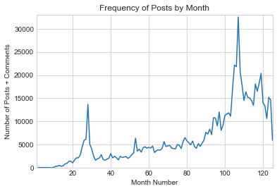

```python
plt.plot(FreqFrame['Frequency'])
plt.xlim(1, 125)
plt.ylim(0, 33000)
plt.title('Frequency of Posts by Month')
plt.xlabel('Month Number')
plt.ylabel('Number of Posts + Comments')
```

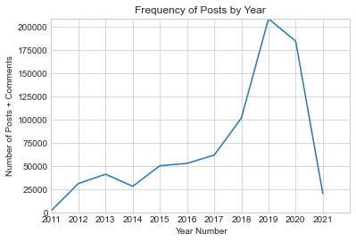

```python
#plt.plot(YearFreqFrame['Frequency'])
plt.plot(YearFreqFrame['Year'], YearFreqFrame['Frequency'])
plt.xlim(1, 12) # number of years in my data
plt.ylim(0, 209000); # up to the max frequency or more
plt.title('Frequency of Posts by Year')
plt.xlabel('Year Number')
plt.ylabel('Number of Posts + Comments')
```

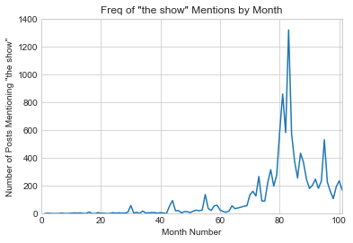

```python
plt.plot(FreqFrameShow['Frequency'])
plt.xlim(0, 101)
plt.ylim(0, 1400)
plt.title('Freq of "the show" Mentions by Month')
plt.xlabel('Month Number')
plt.ylabel('Number of Posts Mentioning "the show"')
```

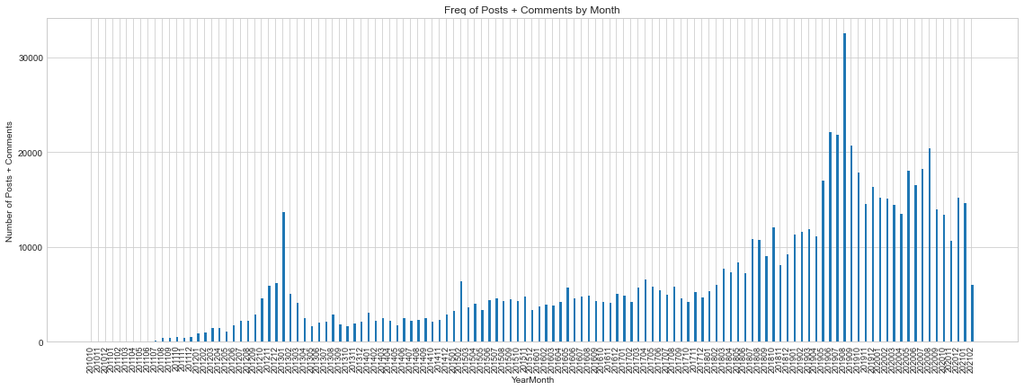

```python
fig = plt.figure(figsize=(15, 5))
ax = fig.add_axes([0,0,1,1])
#ax.set_xlim()
#ax.set_ylim(0, 60)
plt.locator_params(axis='y', nbins=6)
#plt.locator_params(axis='x', nbins=67)
ax.bar(FreqFrame['YearMonth'].astype('str'), FreqFrame['Frequency'], align='edge', width=0.3)
plt.xticks(rotation = 90, size = 9.0)
plt.title('Freq of Posts + Comments by Month')
plt.xlabel('YearMonth')
plt.ylabel('Number of Posts + Comments')
plt.show()
```

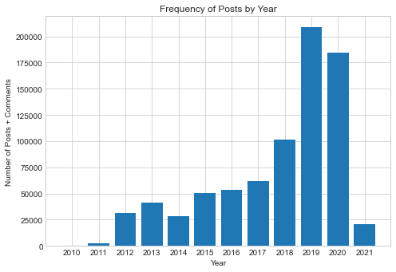

```python
fig = plt.figure()
ax = fig.add_axes([0,0,1,1])
ax.bar(YearFreqFrame['Year'], YearFreqFrame['Frequency'])
plt.title('Frequency of Posts by Year')
plt.xlabel('Year')
plt.ylabel('Number of Posts + Comments')
plt.show()
```

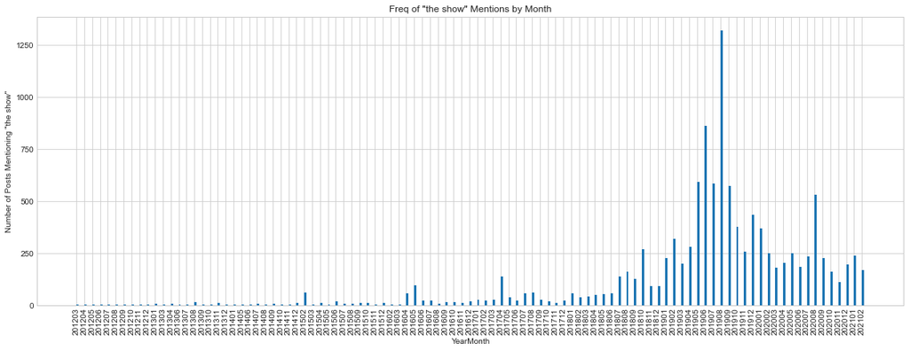

```python
fig = plt.figure(figsize=(15, 5))
ax = fig.add_axes([0,0,1,1])
#ax.set_xlim()
#ax.set_ylim(0, 60)
plt.locator_params(axis='y', nbins=6)
#plt.locator_params(axis='x', nbins=67)
ax.bar(FreqFrameShow['YearMonth'].astype('str'), FreqFrameShow['Frequency'], align='edge', width=0.3)
plt.xticks(rotation = 90, size = 10)
plt.title('Freq of "the show" Mentions by Month')
plt.xlabel('YearMonth')
plt.ylabel('Number of Posts Mentioning "the show"')
plt.show()
```

# Character entries taken from somewhere online, just for referencing names of main chars

- Rand al'Thor: Ta'veren; the main protagonist of the story. The Dragon Reborn, known as the Car'a'carn or He Who Comes with the Dawn to the Aiel, the Coramoor to the Atha'an Miere, and Shadowkiller to the wolves. Born on the slopes of Dragonmount during the Aiel War. The soul of Lews Therin Telamon Kinslayer reborn.
- Matrim Cauthon: Ta'veren; usually called "Mat". He becomes the Marshal General of the Band of the Red Hand, marries the Seanchan empress Fortuona, and becomes one of the greatest generals the world has ever seen. Perrin Aybara: Ta'veren; Perrin is a wolfbrother, and throughout the story becomes quite adept at manipulating Tel'aran'rhiod. Becomes the Lord of the Two Rivers/Steward of the Dragon in the Two Rivers.
- Egwene al'Vere: From Emond's Field herself, she was in training to become a Wisdom before venturing off with Moraine and Lan, where she discovered she could channel. She quickly rises through the ranks of the Aes Sedai, eventually becoming the Amyrlin Seat.
- Nynaeve al'Meara: At the start of the story, she is the Wisdom of Emond's Field. After tracking down the rest of the Emond's Fielders after their departure, she soon finds out she can also channel, eventually becoming an Aes Sedai of the Yellow Ajah, and marries Lan Mandragoran, making her the Queen of Malkier. She is one of the most powerful female channelers alive and a member of the Yellow Ajah, due to her gift with Healing.
- Elayne Trakand: When she first appears, she is the heir to the Lion Throne of Andor, as the only daughter of Queen Morgase Trakand. Later becomes Queen of Andor following her mother's (falsely) presumed death. She is also a powerful channeler, becoming an Aes Sedai of the Green Ajah.
- Moiraine Damodred: Aes Sedai of the Blue Ajah, Moiraine Sedai's arrival to the small village of Emond's Field serves as the inciting incident of the series. Along with her Warder, Lan, Moiraine takes the Emond's Field Five away from their home of the Two Rivers.
- Elmindreda Farshaw: Commonly known as "Min". Originally from Baerlon, Min enters the series because of her unique ability to sometimes see viewings and auras around people which can serve as a kind of divination. She is also (arguably) the main love interest of Rand al'Thor.

# Learn how to strip punctuation from a string

```python
import string

s = "This. Is. A sentence, of Libby's, with? punctuation!"
p = s.translate(str.maketrans('', '', string.punctuation))
print(p)
```

```
This Is A sentence of Libbys with punctuation
```

# Character Name Freqs for the r/Wot subreddit

```python
import json

def json_string_to_dictionary(json_string):
    jsonObject = json.loads(json_string)
    return jsonObject
```

```python
from sklearn.feature_extraction import text

#print(text.ENGLISH_STOP_WORDS)
import string
import pandas as pd
import itertools
```

```python
nameSet = {'Rand', 'Mat', 'Perrin', 'Egwene', 'Nynaeve', 'Elayne', 'Moiraine', 'Min', 'Aviendha'}
namelookup = {'mins':'Min', 'elmindreda': 'Min', 'moirane':'Moiraine', 'moirraine':'Moiraine', 'moirainne':'Moiraine', 'morainne':'Moiraine',
              'morraine':'Moiraine', 'moraine':'Moiraine', 'moiraines':'Moiraine', 'egwenes': 'Egwene',
              'aviendhas': 'Aviendha', 'elaynes': 'Elayne', 'perrins':'Perrin', 'mats':'Mat',
                'rands': 'Rand', 'nynaeves': 'Nynaeve','nyn': 'Nynaeve', 'nyneave': 'Nynaeve',
            'nyneve': 'Nynaeve', 'eg': 'Egwene', 'egg': 'Egwene', 'eggy': 'Egwene',
                'elmindreda': 'Min', 'avi': 'Aviendha', 'avienda': 'Aviendha', 'aviendah': 'Aviendha',
                'matt': 'Mat', 'perin': 'Perrin',
        'elaine':'Elayne', 'elane': 'Elayne'}
nameFreqs = dict.fromkeys(nameSet , 0)
showMentions = 0
wordcounts = {}
rawWordCount = 0
total_number_of_submissions = 0

Wot_dataset = open('WotRedSelf.jsonl', 'r')

for row in Wot_dataset:
    post_dict = json_string_to_dictionary(row)  # Reads one post into a dictionary

    if post_dict['selftext'] != "[deleted]":

        post_text = post_dict['selftext']  # Pulls out the full text of the post and stores it as a string
        if post_text == "":
            continue
        total_number_of_submissions += 1
        for word in post_text.split():
            word = word.translate(str.maketrans('', '', string.punctuation)).lower()
            rawWordCount += 1 # includes all words, even stop words
            if word == 'show':
                showMentions += 1
            if word not in text.ENGLISH_STOP_WORDS:
                wordcounts[word] = wordcounts.get(word, 0) + 1
            if word.title() in nameSet:
                nameFreqs[word.title()] = nameFreqs.get(word.title(), 0) + 1
            if word in namelookup:
                nameFreqs[namelookup[word]] = nameFreqs.get(namelookup[word], 0) + 1
            # checking to see if misspelling is in list and then normalizing it to the same name

Wot_dataset.close()
Wot_dataset = open('WotRedComms.jsonl', 'r')

for row in Wot_dataset:
    post_dict = json_string_to_dictionary(row)  # Reads one post into a dictionary

    if post_dict['body'] != "[deleted]":

        post_text = post_dict['body']  # Pulls out the full text of the post and stores it as a string
        if post_text == "":
            continue
        total_number_of_submissions += 1
        for word in post_text.split():
            word = word.translate(str.maketrans('', '', string.punctuation)).lower()
            rawWordCount += 1 # includes all words, even stop words
            if word == 'show':
                showMentions += 1
            if word not in text.ENGLISH_STOP_WORDS:
                wordcounts[word] = wordcounts.get(word, 0) + 1
            if word.title() in nameSet:
                nameFreqs[word.title()] = nameFreqs.get(word.title(), 0) + 1
            if word in namelookup:
                nameFreqs[namelookup[word]] = nameFreqs.get(namelookup[word], 0) + 1
            # checking to see if misspelling is in list and then normalizing it to the same name

Wot_dataset.close()

maxwords = 0
mostfreqword = ""
for word, count in wordcounts.items():
    if count > maxwords:
        maxwords = count
        mostfreqword = word


wordcounts_sorted = dict(sorted(wordcounts.items(), key=lambda item: -item[1]))
nameFreqs_sorted = dict(sorted(nameFreqs.items(), key=lambda item: -item[1]))

total_number_of_words = rawWordCount
average_number_words_per_submission = total_number_of_words/total_number_of_submissions

print("Total number of submissions: ", total_number_of_submissions)
print("Total words: ", total_number_of_words)
print("Avg words per submission: ", average_number_words_per_submission)
print()
names = pd.Series(nameFreqs_sorted)
print()
print("Total mentions of word 'show': ", showMentions)
print()
freqs = pd.Series(dict(itertools.islice(wordcounts_sorted.items(), 50)))
print(nameFreqs)
```

```
Total number of submissions:  786067
Total words:  38585042
Avg words per submission:  49.08620003129504


Total mentions of word 'show':  32482

{'Egwene': 53688, 'Nynaeve': 38469, 'Perrin': 50702, 'Elayne': 31726, 'Aviendha': 11894, 'Min': 15930, 'Moiraine': 30729, 'Rand': 154345, 'Mat': 66885}
```

# Character Name Freqs for the books

```python
# Get NAME Frequencies for Books!

nameSet = {'Rand', 'Mat', 'Perrin', 'Egwene', 'Nynaeve', 'Elayne', 'Moiraine', 'Min', 'Aviendha'}

namelookup = {'mins':'Min', 'elmindreda': 'Min', 'moirane':'Moiraine', 'moirraine':'Moiraine', 'moirainne':'Moiraine', 'morainne':'Moiraine',
              'morraine':'Moiraine', 'moraine':'Moiraine', 'moiraines':'Moiraine', 'egwenes': 'Egwene',
              'aviendhas': 'Aviendha', 'elaynes': 'Elayne', 'perrins':'Perrin', 'mats':'Mat',
                'rands': 'Rand', 'nynaeves': 'Nynaeve','nyn': 'Nynaeve', 'nyneave': 'Nynaeve',
            'nyneve': 'Nynaeve', 'eg': 'Egwene', 'egg': 'Egwene', 'eggy': 'Egwene',
                'elmindreda': 'Min', 'avi': 'Aviendha', 'avienda': 'Aviendha', 'aviendah': 'Aviendha',
                'matt': 'Mat', 'perin': 'Perrin',
        'elaine':'Elayne', 'elane': 'Elayne'}

#Total frequency of names in all books
nameFreqsBooks = dict.fromkeys(nameSet , 0)

freq_name_dict = {1: dict.fromkeys(nameSet , 0), 2: dict.fromkeys(nameSet , 0),
                   3: dict.fromkeys(nameSet , 0), 4: dict.fromkeys(nameSet , 0),
                   5: dict.fromkeys(nameSet , 0), 6: dict.fromkeys(nameSet , 0),
                   7: dict.fromkeys(nameSet , 0), 8: dict.fromkeys(nameSet , 0),
                   9: dict.fromkeys(nameSet , 0), 10: dict.fromkeys(nameSet , 0),
                   11: dict.fromkeys(nameSet , 0)}
word_count_dict = {1: 0, 2: 0, 3: 0, 4: 0, 5: 0, 6: 0, 7: 0, 8: 0, 9: 0, 10: 0, 11: 0}


for i,book in enumerate(books):
    for line in book.split('. '):
        # What to do for each book
        for word in line.split():
            word = word.translate(str.maketrans('', '', string.punctuation)).lower()
            word_count_dict[i+1] += 1
            if word.title() in nameSet:
                nameFreqsBooks[word.title()] += 1
                freq_name_dict[i+1][word.title()] += 1
            if word in namelookup:
                nameFreqsBooks[namelookup[word]] += 1
                freq_name_dict[i+1][namelookup[word]] += 1
    # What to do after each book
    print("book", i+1, "complete")


total_number_of_words = sum(word_count_dict.values())
```

```
book 1 complete
book 2 complete
book 3 complete
book 4 complete
book 5 complete
book 6 complete
book 7 complete
book 8 complete
book 9 complete
book 10 complete
book 11 complete
```

```python
print(nameFreqsBooks)
```

```
{'Egwene': 5331, 'Nynaeve': 5612, 'Perrin': 4688, 'Elayne': 5549, 'Aviendha': 1759, 'Min': 1844, 'Moiraine': 2650, 'Rand': 10105, 'Mat': 4962}
```

```python
print(freq_name_dict[1])
print(freq_name_dict[2])
print(freq_name_dict[3])
print(freq_name_dict[4])
print(freq_name_dict[5])
print(freq_name_dict[6])
print(freq_name_dict[7])
print(freq_name_dict[8])
print(freq_name_dict[9])
print(freq_name_dict[10])
print(freq_name_dict[11])
```

```
{'Egwene': 581, 'Nynaeve': 367, 'Perrin': 676, 'Elayne': 73, 'Aviendha': 0, 'Min': 30, 'Moiraine': 830, 'Rand': 2109, 'Mat': 1071}
{'Egwene': 617, 'Nynaeve': 550, 'Perrin': 289, 'Elayne': 221, 'Aviendha': 0, 'Min': 247, 'Moiraine': 387, 'Rand': 1710, 'Mat': 409}
{'Egwene': 867, 'Nynaeve': 661, 'Perrin': 681, 'Elayne': 469, 'Aviendha': 43, 'Min': 91, 'Moiraine': 432, 'Rand': 364, 'Mat': 623}
{'Egwene': 673, 'Nynaeve': 660, 'Perrin': 1041, 'Elayne': 652, 'Aviendha': 262, 'Min': 258, 'Moiraine': 518, 'Rand': 1122, 'Mat': 572}
{'Egwene': 518, 'Nynaeve': 1100, 'Perrin': 19, 'Elayne': 864, 'Aviendha': 364, 'Min': 215, 'Moiraine': 351, 'Rand': 1033, 'Mat': 284}
{'Egwene': 699, 'Nynaeve': 930, 'Perrin': 451, 'Elayne': 928, 'Aviendha': 216, 'Min': 285, 'Moiraine': 86, 'Rand': 1568, 'Mat': 523}
{'Egwene': 351, 'Nynaeve': 562, 'Perrin': 398, 'Elayne': 557, 'Aviendha': 137, 'Min': 261, 'Moiraine': 23, 'Rand': 832, 'Mat': 440}
{'Egwene': 292, 'Nynaeve': 325, 'Perrin': 345, 'Elayne': 478, 'Aviendha': 247, 'Min': 115, 'Moiraine': 2, 'Rand': 630, 'Mat': 32}
{'Egwene': 90, 'Nynaeve': 353, 'Perrin': 163, 'Elayne': 553, 'Aviendha': 220, 'Min': 200, 'Moiraine': 6, 'Rand': 387, 'Mat': 333}
{'Egwene': 414, 'Nynaeve': 26, 'Perrin': 358, 'Elayne': 384, 'Aviendha': 180, 'Min': 57, 'Moiraine': 2, 'Rand': 108, 'Mat': 302}
{'Egwene': 229, 'Nynaeve': 78, 'Perrin': 267, 'Elayne': 370, 'Aviendha': 90, 'Min': 85, 'Moiraine': 13, 'Rand': 242, 'Mat': 373}
```

```python
word_count_dict
```

```
{1: 300246,
 2: 260846,
 3: 245202,
 4: 386220,
 5: 344231,
 6: 394265,
 7: 287453,
 8: 222748,
 9: 239077,
 10: 264543,
 11: 321643}
```

```python
total_number_of_words
```

```
3266474
```

# Create a word cloud for fun

```
(-0.5, 399.5, 199.5, -0.5)
```

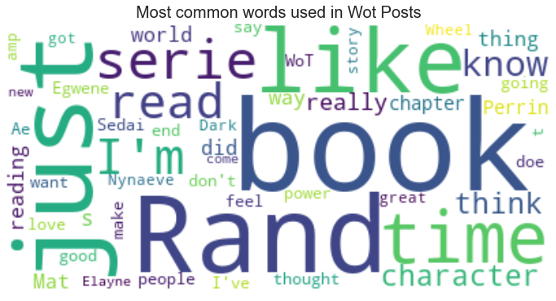

```python
from wordcloud import WordCloud, STOPWORDS, ImageColorGenerator
from sklearn.feature_extraction import text

# Words to not include in Word Clouds
my_stopwords = set(text.ENGLISH_STOP_WORDS)
# Additional phrases I don't want picked up in word clouds
my_stopwords.update(['https', 'http', '\n', '\t', 'removed'])

wot_posts = open('WotRedSelf.jsonl', 'r')
text=""
count=0
for row in wot_posts:
    post_dict = json_string_to_dictionary(row)

    if post_dict['selftext'] != "[deleted]":

        post_text = post_dict['selftext']  # Pulls out the full text of the post and stores it as a string
        if post_text == "":
            continue
        text += post_text
        #count+=1
        #if count == 50000:
            #break
#Creating Selftext Word Cloud
selftext_wc = WordCloud(stopwords = my_stopwords, max_words=50, background_color='white',
                        collocations = False).generate(text)
plt.figure(figsize=(12,10))
plt.imshow(selftext_wc, interpolation='bilinear')
plt.title('Most common words used in Wot Posts', fontsize = 20)
plt.axis('off')
```

```python
nameFreqs
```

[output not shown]

# Learn how to use Spacy and the power lexicon

```python
import spacy

nlp = spacy.load("en_core_web_sm") # parser
```

```python
import csv

lexicon = {}

# Load Power Lexicon. These are verbs that represent power between the subject and object of a sentence.
# for instance "John abandoned Dave" suggests John has more power than Dave. Likewise,
# "John accompanied Dave" suggests Dave has more power than John.

# agent = subject, power_agent is giving power to subject
# theme = object, power_theme is giving power to the object
# power_equal means they have equal

with open('agency_power.csv') as iFile:
    iCSV = csv.reader(iFile, delimiter=',')
    for row in iCSV:
        lemma = [x.lemma_ for x in nlp(row[0])][0]
        lexicon[lemma] = row[2]
```

```python
# This example code shows how to get a score of how people generally view themself

self_lexicon = {'i', 'me', 'myself', 'we', 'our', 'ourself'}  # these are self words focusing on the self perception
# there could be a lexicon just for a single character or all female names/pronouns to see how power is pertrayed for those groups/people

nlp = spacy.load("en_core_web_sm") # loading 'nlp' as the spacy tokenizer

doc = nlp("I abandoned her. He healed me. They punched me.".lower()) # tokenizing string and calling it 'doc' (spacy sees three sents)

# I abandoned her (I - subject, abandoned - predicate/verb, her - object) (I is the self word AND subject, verb gives power to the subject) power_self += 1
# He healed me (He - subject, healed - predicate/verb, me - object) (me is self word AND object, verb gives power to subject) power_self -= 1
# They punched me (They - subject, punched, predicate/verb, me - object) (me is self word AND object, verb gives power to subject) power_self -= 1

power_self  = 0
for sent in doc.sents:  # Iterate over the sentences in the document when sentence boundaries have been set on the document by the parser, senter, sentencizer, etc.
    for token in sent: # each word in the sentence
        #print(token.text, token.head.text, token.dep_) # word, word that's related to our text word, relationship)
        #print()
        if token.head.lemma_ in lexicon: # if the "head" is a verb in our power lexicon, head is the word directly related to this token/word
            if token.text in self_lexicon: # Check if the word is a "self" word (is the head of this token one of the verbs in our lexicon)
                print(token.text, token.head.text, token.dep_) # word, word that's related to our text word, relationship)
                if lexicon[token.head.lemma_] == 'power_theme' and token.dep_ == 'dobj': # If the self word is the object and verb gives power to object, increase power score
                    power_self += 1
                elif lexicon[token.head.lemma_] == 'power_theme' and token.dep_ == 'nsubj': # If the self word is the subject and verb gives power to object, descrease power score.
                    power_self -= 1
                elif lexicon[token.head.lemma_] == 'power_agent' and token.dep_ == 'nsubj': # ? If self word is subject and verb gives power to subject?
                    power_self += 1
                elif lexicon[token.head.lemma_] == 'power_agent' and token.dep_ == 'dobj': # ? If self word is object and verb gives power to subject?
                    power_self -= 1
```

```
i abandoned nsubj
me healed dobj
me punched dobj
```

```python
# Can I use names?

name_lexicon = {'libby'}


nlp = spacy.load("en_core_web_sm") # loading 'nlp' as the spacy tokenizer

doc = nlp("I abandoned Libby. Libby healed Libby. Libby punched me. Libby punished him. Libby helped her. Libby feared her.".lower()) # tokenizing string and calling it 'doc' (spacy sees three sents)

# I abandoned her (I - subject, abandoned - predicate/verb, her - object) (I is the self word AND subject, verb gives power to the subject) power_self += 1
# He healed me (He - subject, healed - predicate/verb, me - object) (me is self word AND object, verb gives power to subject) power_self -= 1
# They punched me (They - subject, punched, predicate/verb, me - object) (me is self word AND object, verb gives power to subject) power_self -= 1

power_self  = 0
power_plus = 0
power_minus = 0
instances = 0
for sent in doc.sents:  # Iterate over the sentences in the document when sentence boundaries have been set on the document by the parser, senter, sentencizer, etc.
    for token in sent: # each word in the sentence
        #print(token.text, token.head.text, token.dep_) # word, word that's related to our text word, relationship)
        #print()
        if token.head.lemma_ in lexicon: # if the "head" is a verb in our power lexicon, head is the word directly related to this token/word
            if token.text in name_lexicon: # Check if the word is a "self" word (is the head of this token one of the verbs in our lexicon)
                print(token.text, token.head.text, token.dep_) # word, word that's related to our text word, relationship)
                if lexicon[token.head.lemma_] == 'power_theme' and token.dep_ == 'dobj': # If the self word is the object and verb gives power to object, increase power score
                    power_self += 1
                    power_plus += 1
                    instances += 1
                    print("+")
                elif lexicon[token.head.lemma_] == 'power_theme' and token.dep_ == 'nsubj': # If the self word is the subject and verb gives power to object, descrease power score.
                    power_self -= 1
                    power_minus += 1
                    instances += 1
                    print("-")
                elif lexicon[token.head.lemma_] == 'power_agent' and token.dep_ == 'nsubj': # ? If self word is subject and verb gives power to subject?
                    power_self += 1
                    power_plus += 1
                    instances += 1
                    print("+")
                elif lexicon[token.head.lemma_] == 'power_agent' and token.dep_ == 'dobj': # ? If self word is object and verb gives power to subject?
                    power_self -= 1
                    power_minus += 1
                    instances += 1
                    print("-")
print("power:", power_self)
print("power+:", power_plus)
print("power-:", power_minus)
print("total instances:", instances)
# Define an instance. An instance is any time when a libby is the subject or the object of an action that denotes power/weakness.
# For example, the sentance, "Libby helped me" show Libby as the subject of the power action "helped"
# In the case of male vs female, there will be sentences which balance out to zero, such as "she healed her" in which
# the female subject is powerful and the female object is weak, creating a "total" power score of zero for the sentence.
# This would be described as two female instances, 50% of which were powerful and 50% weak.

# in this code example above, "Libby helped" is neutral - "power_equal" in the power lexicon tagging system
```

```
libby abandoned dobj
-
libby healed nsubj
+
libby healed dobj
-
libby punched nsubj
+
libby punished nsubj
+
libby helped nsubj
libby feared nsubj
-
power: 0
power+: 3
power-: 3
total instances: 6
```

```python
print(power_self)
```

```
0
```

# Analyze Male and Female power and submissiveness in the r/Wot subreddit

```python
import spacy

nlp = spacy.load("en_core_web_sm") # parser

import csv

lexicon = {}

# Load Power Lexicon. These are verbs that represent power between the subject and object of a sentence.
# for instance "John abandoned Dave" suggests John has more power than Dave. Likewise,
# "John accompanied Dave" suggests Dave has more power than John.

# agent = subject, power_agent is giving power to subject
# theme = object, power_theme is giving power to the object
# power_equal means they have equal

with open('agency_power.csv') as iFile:
    iCSV = csv.reader(iFile, delimiter=',')
    for row in iCSV:
        lemma = [x.lemma_ for x in nlp(row[0])][0]
        lexicon[lemma] = row[2]
```

```python
import json

def json_string_to_dictionary(json_string):
    jsonObject = json.loads(json_string)
    return jsonObject
```

```python
# female power on r/Wot
power_female  = 0
power_female_plus  = 0
power_female_minus  = 0
power_female_total = 0


female_lexicon = {'she', 'her', 'hers'}

infile = open('WotRedSelf.jsonl', 'r')

for row in infile:
    post_dict = json_string_to_dictionary(row)

    if post_dict['selftext'] != "[deleted]":

        post_text = post_dict['selftext']  # Pulls out the full text of the post and stores it as a string
        if post_text == "":
            continue
        doc = nlp(post_text.lower())
        for sent in doc.sents:  # Iterate over the sentences in the document when sentence boundaries have been set on the document by the parser, senter, sentencizer, etc.
            for token in sent: # each word in the sentence
                if token.head.lemma_ in lexicon: # if the "head" is a verb in our power lexicon, head is the word directly related to this token/word
                    if token.text in female_lexicon: # Check if the word is a "self" word (is the head of this token one of the verbs in our lexicon)

                        if lexicon[token.head.lemma_] == 'power_theme' and token.dep_ == 'dobj': # If female is the object and verb gives power to object, increase power score
                            power_female += 1
                            power_female_plus += 1
                            power_female_total += 1
                        elif lexicon[token.head.lemma_] == 'power_theme' and token.dep_ == 'nsubj': # If female is the subject and verb gives power to object, descrease power score.
                            power_female -= 1
                            power_female_minus += 1
                            power_female_total += 1
                        elif lexicon[token.head.lemma_] == 'power_agent' and token.dep_ == 'nsubj': # ? If female is subject and verb gives power to subject?
                            power_female += 1
                            power_female_plus += 1
                            power_female_total += 1
                        elif lexicon[token.head.lemma_] == 'power_agent' and token.dep_ == 'dobj': # ? If female is object and verb gives power to subject?
                            power_female -= 1
                            power_female_minus += 1
                            power_female_total += 1
infile.close()

infile = open('WotRedComms.jsonl', 'r')
for row in infile:
    post_dict = json_string_to_dictionary(row)

    if post_dict['body'] != "[deleted]":

        post_text = post_dict['body']  # Pulls out the full text of the post and stores it as a string
        if post_text == "":
            continue
        doc = nlp(post_text.lower())
        for sent in doc.sents:  # Iterate over the sentences in the document when sentence boundaries have been set on the document by the parser, senter, sentencizer, etc.
            for token in sent: # each word in the sentence
                if token.head.lemma_ in lexicon: # if the "head" is a verb in our power lexicon, head is the word directly related to this token/word
                    if token.text in female_lexicon: # Check if the word is a "self" word (is the head of this token one of the verbs in our lexicon)

                        if lexicon[token.head.lemma_] == 'power_theme' and token.dep_ == 'dobj': # If female is the object and verb gives power to object, increase power score
                            power_female += 1
                            power_female_plus += 1
                            power_female_total += 1
                        elif lexicon[token.head.lemma_] == 'power_theme' and token.dep_ == 'nsubj': # If female is the subject and verb gives power to object, descrease power score.
                            power_female -= 1
                            power_female_minus += 1
                            power_female_total += 1
                        elif lexicon[token.head.lemma_] == 'power_agent' and token.dep_ == 'nsubj': # ? If female is subject and verb gives power to subject?
                            power_female += 1
                            power_female_plus += 1
                            power_female_total += 1
                        elif lexicon[token.head.lemma_] == 'power_agent' and token.dep_ == 'dobj': # ? If female is object and verb gives power to subject?
                            power_female -= 1
                            power_female_minus += 1
                            power_female_total += 1
infile.close()
```

```python
power_female_plus
```

```
78455
```

```python
power_female_minus
```

```
33654
```

```python
power_female
```

```
44801
```

```python
power_female_total
```

```
112109
```

```python
# male power on r/Wot
power_male  = 0
power_male_plus  = 0
power_male_minus  = 0
power_male_total = 0
male_lexicon = {'he', 'him', 'his'}

infile = open('WotRedSelf.jsonl', 'r')

for row in infile:
    post_dict = json_string_to_dictionary(row)

    if post_dict['selftext'] != "[deleted]":

        post_text = post_dict['selftext']  # Pulls out the full text of the post and stores it as a string
        if post_text == "":
            continue
        doc = nlp(post_text.lower())
        for sent in doc.sents:  # Iterate over the sentences in the document when sentence boundaries have been set on the document by the parser, senter, sentencizer, etc.
            for token in sent: # each word in the sentence
                if token.head.lemma_ in lexicon: # if the "head" is a verb in our power lexicon, head is the word directly related to this token/word
                    if token.text in male_lexicon: # Check if the word is a "self" word (is the head of this token one of the verbs in our lexicon)

                        if lexicon[token.head.lemma_] == 'power_theme' and token.dep_ == 'dobj': # If female is the object and verb gives power to object, increase power score
                            power_male += 1
                            power_male_plus += 1
                            power_male_total += 1
                        elif lexicon[token.head.lemma_] == 'power_theme' and token.dep_ == 'nsubj': # If female is the subject and verb gives power to object, descrease power score.
                            power_male -= 1
                            power_male_minus += 1
                            power_male_total += 1
                        elif lexicon[token.head.lemma_] == 'power_agent' and token.dep_ == 'nsubj': # ? If female is subject and verb gives power to subject?
                            power_male += 1
                            power_male_plus += 1
                            power_male_total += 1
                        elif lexicon[token.head.lemma_] == 'power_agent' and token.dep_ == 'dobj': # ? If female is object and verb gives power to subject?
                            power_male -= 1
                            power_male_minus += 1
                            power_male_total += 1
infile.close()

infile = open('WotRedComms.jsonl', 'r')
for row in infile:
    post_dict = json_string_to_dictionary(row)

    if post_dict['body'] != "[deleted]":

        post_text = post_dict['body']  # Pulls out the full text of the post and stores it as a string
        if post_text == "":
            continue
        doc = nlp(post_text.lower())
        for sent in doc.sents:  # Iterate over the sentences in the document when sentence boundaries have been set on the document by the parser, senter, sentencizer, etc.
            for token in sent: # each word in the sentence
                if token.head.lemma_ in lexicon: # if the "head" is a verb in our power lexicon, head is the word directly related to this token/word
                    if token.text in male_lexicon: # Check if the word is a "self" word (is the head of this token one of the verbs in our lexicon)

                        if lexicon[token.head.lemma_] == 'power_theme' and token.dep_ == 'dobj': # If female is the object and verb gives power to object, increase power score
                            power_male += 1
                            power_male_plus += 1
                            power_male_total += 1
                        elif lexicon[token.head.lemma_] == 'power_theme' and token.dep_ == 'nsubj': # If female is the subject and verb gives power to object, descrease power score.
                            power_male -= 1
                            power_male_minus += 1
                            power_male_total += 1
                        elif lexicon[token.head.lemma_] == 'power_agent' and token.dep_ == 'nsubj': # ? If female is subject and verb gives power to subject?
                            power_male += 1
                            power_male_plus += 1
                            power_male_total += 1
                        elif lexicon[token.head.lemma_] == 'power_agent' and token.dep_ == 'dobj': # ? If female is object and verb gives power to subject?
                            power_male -= 1
                            power_male_minus += 1
                            power_male_total += 1
infile.close()
```

```python
power_male_plus
```

```
119554
```

```python
power_male_minus
```

```
56102
```

```python
power_male
```

```
63452
```

```python
power_male_total
```

```
175656
```

# Analyze Male and Female power and submissiveness in the r/books subreddit

```python
# female power on r/books
bpower_female  = 0
bpower_female_plus  = 0
bpower_female_minus  = 0
bpower_female_total = 0


female_lexicon = {'she', 'her', 'hers'}

infile = open('rbooksSelf.jsonl', 'r')

for row in infile:
    post_dict = json_string_to_dictionary(row)

    if post_dict['selftext'] != "[deleted]":

        post_text = post_dict['selftext']  # Pulls out the full text of the post and stores it as a string
        if post_text == "":
            continue
        doc = nlp(post_text.lower())
        for sent in doc.sents:  # Iterate over the sentences in the document when sentence boundaries have been set on the document by the parser, senter, sentencizer, etc.
            for token in sent: # each word in the sentence
                if token.head.lemma_ in lexicon: # if the "head" is a verb in our power lexicon, head is the word directly related to this token/word
                    if token.text in female_lexicon: # Check if the word is a "self" word (is the head of this token one of the verbs in our lexicon)

                        if lexicon[token.head.lemma_] == 'power_theme' and token.dep_ == 'dobj': # If female is the object and verb gives power to object, increase power score
                            bpower_female += 1
                            bpower_female_plus += 1
                            bpower_female_total += 1
                        elif lexicon[token.head.lemma_] == 'power_theme' and token.dep_ == 'nsubj': # If female is the subject and verb gives power to object, descrease power score.
                            bpower_female -= 1
                            bpower_female_minus += 1
                            bpower_female_total += 1
                        elif lexicon[token.head.lemma_] == 'power_agent' and token.dep_ == 'nsubj': # ? If female is subject and verb gives power to subject?
                            bpower_female += 1
                            bpower_female_plus += 1
                            bpower_female_total += 1
                        elif lexicon[token.head.lemma_] == 'power_agent' and token.dep_ == 'dobj': # ? If female is object and verb gives power to subject?
                            bpower_female -= 1
                            bpower_female_minus += 1
                            bpower_female_total += 1
infile.close()

infile = open('rbooksComms.jsonl', 'r')
for row in infile:
    post_dict = json_string_to_dictionary(row)

    if post_dict['body'] != "[deleted]":

        post_text = post_dict['body']  # Pulls out the full text of the post and stores it as a string
        if post_text == "":
            continue
        doc = nlp(post_text.lower())
        for sent in doc.sents:  # Iterate over the sentences in the document when sentence boundaries have been set on the document by the parser, senter, sentencizer, etc.
            for token in sent: # each word in the sentence
                if token.head.lemma_ in lexicon: # if the "head" is a verb in our power lexicon, head is the word directly related to this token/word
                    if token.text in female_lexicon: # Check if the word is a "self" word (is the head of this token one of the verbs in our lexicon)

                        if lexicon[token.head.lemma_] == 'power_theme' and token.dep_ == 'dobj': # If female is the object and verb gives power to object, increase power score
                            bpower_female += 1
                            bpower_female_plus += 1
                            bpower_female_total += 1
                        elif lexicon[token.head.lemma_] == 'power_theme' and token.dep_ == 'nsubj': # If female is the subject and verb gives power to object, descrease power score.
                            bpower_female -= 1
                            bpower_female_minus += 1
                            bpower_female_total += 1
                        elif lexicon[token.head.lemma_] == 'power_agent' and token.dep_ == 'nsubj': # ? If female is subject and verb gives power to subject?
                            bpower_female += 1
                            bpower_female_plus += 1
                            bpower_female_total += 1
                        elif lexicon[token.head.lemma_] == 'power_agent' and token.dep_ == 'dobj': # ? If female is object and verb gives power to subject?
                            bpower_female -= 1
                            bpower_female_minus += 1
                            bpower_female_total += 1
infile.close()





#####################################################################
# male power on r/books
bpower_male  = 0
bpower_male_plus  = 0
bpower_male_minus  = 0
bpower_male_total = 0
male_lexicon = {'he', 'him', 'his'}

infile = open('rbooksSelf.jsonl', 'r')

for row in infile:
    post_dict = json_string_to_dictionary(row)

    if post_dict['selftext'] != "[deleted]":

        post_text = post_dict['selftext']  # Pulls out the full text of the post and stores it as a string
        if post_text == "":
            continue
        doc = nlp(post_text.lower())
        for sent in doc.sents:  # Iterate over the sentences in the document when sentence boundaries have been set on the document by the parser, senter, sentencizer, etc.
            for token in sent: # each word in the sentence
                if token.head.lemma_ in lexicon: # if the "head" is a verb in our power lexicon, head is the word directly related to this token/word
                    if token.text in male_lexicon: # Check if the word is a "self" word (is the head of this token one of the verbs in our lexicon)

                        if lexicon[token.head.lemma_] == 'power_theme' and token.dep_ == 'dobj': # If female is the object and verb gives power to object, increase power score
                            bpower_male += 1
                            bpower_male_plus += 1
                            bpower_male_total += 1
                        elif lexicon[token.head.lemma_] == 'power_theme' and token.dep_ == 'nsubj': # If female is the subject and verb gives power to object, descrease power score.
                            bpower_male -= 1
                            bpower_male_minus += 1
                            bpower_male_total += 1
                        elif lexicon[token.head.lemma_] == 'power_agent' and token.dep_ == 'nsubj': # ? If female is subject and verb gives power to subject?
                            bpower_male += 1
                            bpower_male_plus += 1
                            bpower_male_total += 1
                        elif lexicon[token.head.lemma_] == 'power_agent' and token.dep_ == 'dobj': # ? If female is object and verb gives power to subject?
                            bpower_male -= 1
                            bpower_male_minus += 1
                            bpower_male_total += 1
infile.close()

infile = open('rbooksComms.jsonl', 'r')
for row in infile:
    post_dict = json_string_to_dictionary(row)

    if post_dict['body'] != "[deleted]":

        post_text = post_dict['body']  # Pulls out the full text of the post and stores it as a string
        if post_text == "":
            continue
        doc = nlp(post_text.lower())
        for sent in doc.sents:  # Iterate over the sentences in the document when sentence boundaries have been set on the document by the parser, senter, sentencizer, etc.
            for token in sent: # each word in the sentence
                if token.head.lemma_ in lexicon: # if the "head" is a verb in our power lexicon, head is the word directly related to this token/word
                    if token.text in male_lexicon: # Check if the word is a "self" word (is the head of this token one of the verbs in our lexicon)

                        if lexicon[token.head.lemma_] == 'power_theme' and token.dep_ == 'dobj': # If female is the object and verb gives power to object, increase power score
                            bpower_male += 1
                            bpower_male_plus += 1
                            bpower_male_total += 1
                        elif lexicon[token.head.lemma_] == 'power_theme' and token.dep_ == 'nsubj': # If female is the subject and verb gives power to object, descrease power score.
                            bpower_male -= 1
                            bpower_male_minus += 1
                            bpower_male_total += 1
                        elif lexicon[token.head.lemma_] == 'power_agent' and token.dep_ == 'nsubj': # ? If female is subject and verb gives power to subject?
                            bpower_male += 1
                            bpower_male_plus += 1
                            bpower_male_total += 1
                        elif lexicon[token.head.lemma_] == 'power_agent' and token.dep_ == 'dobj': # ? If female is object and verb gives power to subject?
                            bpower_male -= 1
                            bpower_male_minus += 1
                            bpower_male_total += 1
infile.close()
```

```python
print("bpower_male:", bpower_male)
print("bpower_male_plus:", bpower_male_plus)
print("bpower_male_minus:", bpower_male_minus)
print("bpower_male_total:", bpower_male_total)
```

```
bpower_male: 4775
bpower_male_plus: 7788
bpower_male_minus: 3013
bpower_male_total: 10801
```

```python
print("bpower_female:", bpower_female)
print("bpower_female_plus:", bpower_female_plus)
print("bpower_female_minus:", bpower_female_minus)
print("bpower_female_total:", bpower_female_total)
```

```
bpower_female: 1833
bpower_female_plus: 3394
bpower_female_minus: 1561
bpower_female_total: 4955
```

# Creating the book text objects from .txt files

```python
# Think of one book.txt as one submission
b1 = open('./Books/1TheEyeOfTheWorld.txt', encoding="utf8")

book1_txt = b1.read()

b1.close()

b2 = open('./Books/2TheGreatHunt.txt', encoding="utf8")

book2_txt = b2.read()

b2.close()

b3 = open('./Books/3TheDragonReborn.txt', encoding="utf8")

book3_txt = b3.read()

b3.close()

b4 = open('./Books/4TheShadowRising.txt', encoding="utf8")

book4_txt = b4.read()

b4.close()

b5 = open('./Books/5TheFiresOfHeaven.txt', encoding="utf8")

book5_txt = b5.read()

b5.close()

b6 = open('./Books/6LordOfChaos.txt', encoding="utf8")

book6_txt = b6.read()

b6.close()

b7 = open('./Books/7CrownOfSwords.txt', encoding="utf8")

book7_txt = b7.read()

b7.close()

b8 = open('./Books/8PathOfDaggers.txt', encoding="utf8")

book8_txt = b8.read()

b8.close()

b9 = open('./Books/9WintersHeart.txt', encoding="utf8")

book9_txt = b9.read()

b9.close()

b10 = open('./Books/10CrossroadsOfTwilight.txt', encoding="utf8")

book10_txt = b10.read()

b10.close()

b11 = open('./Books/11KnifeOfDreams.txt', encoding="utf8")

book11_txt = b11.read()

b11.close()

books = [book1_txt, book2_txt, book3_txt, book4_txt, book5_txt, book6_txt,
         book7_txt, book8_txt, book9_txt, book10_txt, book11_txt]
```

```python
import spacy

nlp = spacy.load("en_core_web_sm") # parser

import csv

lexicon = {}

# Load Power Lexicon. These are verbs that represent power between the subject and object of a sentence.
# for instance "John abandoned Dave" suggests John has more power than Dave. Likewise,
# "John accompanied Dave" suggests Dave has more power than John.

# agent = subject, power_agent is giving power to subject
# theme = object, power_theme is giving power to the object
# power_equal means they have equal

with open('agency_power.csv') as iFile:
    iCSV = csv.reader(iFile, delimiter=',')
    for row in iCSV:
        lemma = [x.lemma_ for x in nlp(row[0])][0]
        lexicon[lemma] = row[2]
```

# Analyze Male and Female power and submissiveness in the books

```python
# books - male power
male_lexicon = {'he', 'him', 'his'}

male_power_dict = {1: 0, 2: 0, 3: 0, 4: 0, 5: 0, 6: 0, 7: 0, 8: 0, 9: 0, 10: 0, 11: 0}
male_power_plus_dict = {1: 0, 2: 0, 3: 0, 4: 0, 5: 0, 6: 0, 7: 0, 8: 0, 9: 0, 10: 0, 11: 0}
male_power_minus_dict = {1: 0, 2: 0, 3: 0, 4: 0, 5: 0, 6: 0, 7: 0, 8: 0, 9: 0, 10: 0, 11: 0}
male_power_tot_dict = {1: 0, 2: 0, 3: 0, 4: 0, 5: 0, 6: 0, 7: 0, 8: 0, 9: 0, 10: 0, 11: 0}

for i,book in enumerate(books):
    for line in book.split('. '):
        doc = nlp(line.lower())
        for sent in doc.sents:  # Iterate over the sentences in the document when sentence boundaries have been set on the document by the parser, senter, sentencizer, etc.
            for token in sent: # each word in the sentence
                if token.head.lemma_ in lexicon: # if the "head" is a verb in our power lexicon, head is the word directly related to this token/word
                    if token.text in male_lexicon: # Check if the word is a "self" word (is the head of this token one of the verbs in our lexicon)

                        if lexicon[token.head.lemma_] == 'power_theme' and token.dep_ == 'dobj': # If female is the object and verb gives power to object, increase power score
                            male_power_dict[i+1] += 1
                            male_power_plus_dict[i+1] += 1
                            male_power_tot_dict[i+1] += 1
                        elif lexicon[token.head.lemma_] == 'power_theme' and token.dep_ == 'nsubj': # If female is the subject and verb gives power to object, descrease power score.
                            male_power_dict[i+1] -= 1
                            male_power_minus_dict[i+1] += 1
                            male_power_tot_dict[i+1] += 1
                        elif lexicon[token.head.lemma_] == 'power_agent' and token.dep_ == 'nsubj': # ? If female is subject and verb gives power to subject?
                            male_power_dict[i+1] += 1
                            male_power_plus_dict[i+1] += 1
                            male_power_tot_dict[i+1] += 1
                        elif lexicon[token.head.lemma_] == 'power_agent' and token.dep_ == 'dobj': # ? If female is object and verb gives power to subject?
                            male_power_dict[i+1] -= 1
                            male_power_minus_dict[i+1] += 1
                            male_power_tot_dict[i+1] += 1
    print("book", i+1, "complete")
```

```
book 1 complete
book 2 complete
book 3 complete
book 4 complete
book 5 complete
book 6 complete
book 7 complete
book 8 complete
book 9 complete
book 10 complete
book 11 complete
```

```python
male_power_dict
```

```
{1: 1321,
 2: 763,
 3: 816,
 4: 1100,
 5: 1071,
 6: 1077,
 7: 697,
 8: 422,
 9: 599,
 10: 651,
 11: 770}
```

```python
sum(male_power_dict.values())
```

```
9287
```

```python
male_power_plus_dict
```

```
{1: 2412,
 2: 1621,
 3: 1555,
 4: 2517,
 5: 2102,
 6: 2333,
 7: 1496,
 8: 918,
 9: 1255,
 10: 1206,
 11: 1519}
```

```python
sum(male_power_plus_dict.values())
```

```
18934
```

```python
male_power_minus_dict
```

```
{1: 1091,
 2: 858,
 3: 739,
 4: 1417,
 5: 1031,
 6: 1256,
 7: 799,
 8: 496,
 9: 656,
 10: 555,
 11: 749}
```

```python
sum(male_power_minus_dict.values())
```

```
9647
```

```python
male_power_tot_dict
```

```
{1: 3503,
 2: 2479,
 3: 2294,
 4: 3934,
 5: 3133,
 6: 3589,
 7: 2295,
 8: 1414,
 9: 1911,
 10: 1761,
 11: 2268}
```

```python
sum(male_power_tot_dict.values())
```

```
28581
```

```python
# books - female power
female_lexicon = {'she', 'her', 'hers'}

female_power_dict = {1: 0, 2: 0, 3: 0, 4: 0, 5: 0, 6: 0, 7: 0, 8: 0, 9: 0, 10: 0, 11: 0}
female_power_plus_dict = {1: 0, 2: 0, 3: 0, 4: 0, 5: 0, 6: 0, 7: 0, 8: 0, 9: 0, 10: 0, 11: 0}
female_power_minus_dict = {1: 0, 2: 0, 3: 0, 4: 0, 5: 0, 6: 0, 7: 0, 8: 0, 9: 0, 10: 0, 11: 0}
female_power_tot_dict = {1: 0, 2: 0, 3: 0, 4: 0, 5: 0, 6: 0, 7: 0, 8: 0, 9: 0, 10: 0, 11: 0}

for i,book in enumerate(books):
    for line in book.split('. '):
        doc = nlp(line.lower())
        for sent in doc.sents:  # Iterate over the sentences in the document when sentence boundaries have been set on the document by the parser, senter, sentencizer, etc.
            for token in sent: # each word in the sentence
                if token.head.lemma_ in lexicon: # if the "head" is a verb in our power lexicon, head is the word directly related to this token/word
                    if token.text in female_lexicon: # Check if the word is a "self" word (is the head of this token one of the verbs in our lexicon)

                        if lexicon[token.head.lemma_] == 'power_theme' and token.dep_ == 'dobj': # If female is the object and verb gives power to object, increase power score
                            female_power_dict[i+1] += 1
                            female_power_plus_dict[i+1] += 1
                            female_power_tot_dict[i+1] += 1
                        elif lexicon[token.head.lemma_] == 'power_theme' and token.dep_ == 'nsubj': # If female is the subject and verb gives power to object, descrease power score.
                            female_power_dict[i+1] -= 1
                            female_power_minus_dict[i+1] += 1
                            female_power_tot_dict[i+1] += 1
                        elif lexicon[token.head.lemma_] == 'power_agent' and token.dep_ == 'nsubj': # ? If female is subject and verb gives power to subject?
                            female_power_dict[i+1] += 1
                            female_power_plus_dict[i+1] += 1
                            female_power_tot_dict[i+1] += 1
                        elif lexicon[token.head.lemma_] == 'power_agent' and token.dep_ == 'dobj': # ? If female is object and verb gives power to subject?
                            female_power_dict[i+1] -= 1
                            female_power_minus_dict[i+1] += 1
                            female_power_tot_dict[i+1] += 1
    print("book", i+1, "complete")
```

```
book 1 complete
book 2 complete
book 3 complete
book 4 complete
book 5 complete
book 6 complete
book 7 complete
book 8 complete
book 9 complete
book 10 complete
book 11 complete
```

```python
female_power_dict
```

```
{1: 354,
 2: 529,
 3: 582,
 4: 983,
 5: 1175,
 6: 1022,
 7: 1033,
 8: 653,
 9: 812,
 10: 900,
 11: 940}
```

```python
sum(female_power_dict.values())
```

```
8983
```

```python
female_power_plus_dict
```

```
{1: 651,
 2: 988,
 3: 1099,
 4: 1965,
 5: 2302,
 6: 2252,
 7: 1962,
 8: 1373,
 9: 1727,
 10: 1707,
 11: 2042}
```

```python
sum(female_power_plus_dict.values())
```

```
18068
```

```python
female_power_minus_dict
```

```
{1: 297,
 2: 459,
 3: 517,
 4: 982,
 5: 1127,
 6: 1230,
 7: 929,
 8: 720,
 9: 915,
 10: 807,
 11: 1102}
```

```python
sum(female_power_minus_dict.values())
```

```
9085
```

```python
female_power_tot_dict
```

```
{1: 948,
 2: 1447,
 3: 1616,
 4: 2947,
 5: 3429,
 6: 3482,
 7: 2891,
 8: 2093,
 9: 2642,
 10: 2514,
 11: 3144}
```

```python
sum(female_power_tot_dict.values())
```

```
27153
```